# Manuscript

Author

Kendra Wyant and Jeongyeol Kwon

Published

February 26, 2025

# Introduction

Personal sensing is the collection and analyses of data collected via smartphone and other digital devices in the context of one’s day-to-day life (Mohr, Zhang, and Schueller 2017).

Personal sensing data can be used as inputs into machine learning algorithms to predict important psychological clinical outcomes. Existing literature suggests behavior (substance use (Wyant et al. 2024, in prep; Chih et al. 2014; Businelle et al. 2016; Hébert et al. 2021; S. Bae et al. 2018; Walters et al. 2021; Roberts et al. 2022; S. W. Bae et al. 2023)), mood (depression (Jacobson and Chung 2020; Kim et al. 2019; Razavi, Gharipour, and Gharipour 2020); anxiety (Jacobson and Bhattacharya 2022)), cognitive processes (craving (Epstein et al. 2020; Dumortier et al. 2016); suicidal thoughts (Czyz et al. 2023)), and even future mental health diagnoses (Horwitz et al. (2024)) can be predicted with high accuracy and temporal precision from personal sensing data.

Many mental health disorders, like substance use disorders, depression, and schizophrenia, are chronic conditions. After initial treatment and symptom reduction, individuals must continue to monitor their symptoms. Machine learning models can help individuals self-monitor their risk for risk for symptom-relapse and provide information about the top features contributing to their risk.

EMA offers insight into known risk-relevant feelings, thoughts and behaviors. As such it is not surprising that it has been demonstrated to be highly predictive of lapse.

EMA items are also often easily mapped on to support recommendations and targets for interventions. For example, in the relapse prevention model there are established tools and clinical recommendations for coping with strong cravings, stressful situations, and risky situations.

Typically these models rely on densely sampled EMA (e.g. 4 times daily). While it appears frequent EMA sampling can be sustainable for discrete sampling periods (e.g. 1-3 months) (Wyant et al. 2023; Jones et al. 2019). It is less clear whether such sampling rates can be maintained indefinitely (as is the case for lapse monitoring, where a lapse can occur at any point in one’s recovery and recovery is considered to be a dynamic and long term path).

For example, frequent prompts each day could become burdensome and engagement becomes sparse. Similarly individuals could become bored with the repetitive nature of questions leading to careless or automatic responding.

Wyant et al. (2024) have developed a machine learning model that can predict alcohol lapse risk using 4x daily EMA.

We seek to apply a precision medicine approach to EMA sampling so that individuals are only prompted to complete an EMA analysis when the information is needed to for accurate lapse predictions.

# Methods

## Data Analytic Strategy

Models were run on an NVIDIA GeForce RTX 3090.

### Model Architecture

We formulate the survey design problem as offline reinforcement learning (RL). Specifically, we model the interaction with each participant as an episode. Our goal is to design a survey plan that maximizes the expected cumulative rewards (and minimize penalties) over all participants during the entire episodes. That is, we consider each participant as a new environment instantiated out of $N$ environments; each environment is simulated based on the offline survey data collected in.

In each episode with a participant, at each $t^{th}$ time-step, we either ask (1) whether or not to reveal the survey, or (2) to predict the next 24-hour window lapse. When we get the next survey $X_t$ from the participant (the former), we choose a binary action at deciding whether to reveal the survey or not; that is, we do not observe the survey ot = 0 without penalty if at = 0, and observe the received survey ot = Xt if at = 1, with a penalty depending on penalty levels. This penalty level is a control factor that balances the survey frequency and the prediction accuracy. If the environment asks to predict the next 24-hour window lapse event yt (the latter), an agent does not get any observation, only getting a hidden reward/penalty depending on whether the prediction is correct.

More specifically, our training pipeline can be described as consisting of three networks (summarizer network, policy network, prediction network; Figure 1).

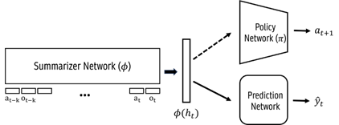

Figure 1: Architecture for two-phase training.

#### 1. Summarizer Network

Our default configuration employs transformer architectures for the summarizing model. For implementing the transformer model, we adhere to the minimal implementation of NanoGPT’s standard framework1. We use an Embedding layer for discrete actions. For the policy network, we employ the soft actor-critic method for discrete actions (SACD). We use the base two-layer fully-connected architecture for both actor and critic networks. The lapse prediction network uses a single Gated Recurrent Unit (GRU) network.

#### 2. Policy Network

In this phase, the goal is to learn a survey policy that maximizes the cumulative returns – the sum of all rewards and penalties – averaged over all participants. The policy takes all 25 k-step previous observations, which we call a historical context or simply history, and decides an action to take. We let k = 25 in our experiments.

New trajectories are generated with φ and the current policy π, which takes a summary statistics φ(ht) as an input and outputs the next action. π is updated to maximize the long-term returns of the system.

We considered four penalty levels (LV) that penalized the model for each survey observation shown: -.02, -.05, -.08, and -.12. Models also learned from penalties and rewards related to the accuracy of their predicted lapses. Models were rewarded .05 or .03 for correctly labeling a lapse or no lapse, respectively. Models were penalized -.2 or -1.2 for incorrectly labeling a lapse or no lapse, respectively.

#### 3. Prediction Network

Predictions were made into 24-hour windows (i.e., the probability of a lapse in the next 24 hours). The first prediction window for each participant started 24 hours from midnight on their study start date. Subsequent prediction window start times for each participant repeatedly rolled forward hour-by-hour until the end of their study participation.

The start and end date/time of past drinking episodes were reported on the first EMA item. A prediction window was labeled lapse if the start date/hour of any drinking episode fell within that window. A window was labeled no lapse if no alcohol use occurred within that window +/- 24 hours. If no alcohol use occurred within the window but did occur within 24 hours of the start or end of the window, the window was excluded. We ended up with a total of 274,179 labels.

We used 3 repeats of 10-fold cross-validation to evaluate our models with auROC. auROC indexes the probability that the model will predict a higher score for a randomly selected positive case (lapse) relative to a randomly selected negative case (no lapse). We used grouped cross-validation to assign all data from a participant as either held-in or held-out to avoid bias introduced when predicting a participant’s data from their own data.

The truncated k-step history ht = (ot−k, at−k, …, ot) is input into the history summarization model φ(·), yielding summary statistics φ(ht). Then, this summary statistics is fed into the prediction network to predict the next lapse label. The sequence model φ is updated to minimize the prediction loss in this phase.

### Model Evaluation

#### Bayesian Model

We used a Bayesian hierarchical generalized linear model to estimate the posterior probability distributions and 95% Bayesian credible intervals (CIs) from the 30 held-out test sets for our five best models (no penalty, Lv1, Lv2, Lv3, and Lv4). We used the default weakly informative priors. We set two random intercepts to account for our resampling method: one for the repeat, and another for the fold nested within repeat.

From the Bayesian model we obtained the posterior distribution (transformed back from logit) and Bayeisan CIs for auROCs all five models. To evaluate our models’ overall performance we report the median posterior probability for auROC and Bayesian CIs. This represents our best estimate for the magnitude of the auROC parameter for each model.

We then conducted Bayesian model comparisons to determine the probability that the penalized models’ performances differed systematically from the baseline (no penalty) model. We also report the precise posterior probability for the difference in auROCs and the 95% Bayesian CIs for these comparisons.

## Results

### EMA Adherence and Sampling Frequency

Participants on average completed 3.1 (SD=0.6) of the 4 EMAs each day (78.4% adherence overall). Across the twelve weeks on study, EMA adherence ranged from 75.3% to 86.8%.

The baseline (no penalty) model used all available EMA observations for all participants (proportion of EMAs used = 1.0). As penalties for revealing an EMA observation became higher, overall sampling frequency for EMA observations decreased. The median proportion of EMAs used in the penalized models were .41 (range = .24 - .56), .24 (range = .16 - .34), .12 (range .03 - .20), and .04 (range = 0 - .10) for Lv1, Lv2, Lv3, and Lv4 respectively.

Figure Figure 2 presents histograms that display the distribution of the proportion of EMA observations revealed for each participant.

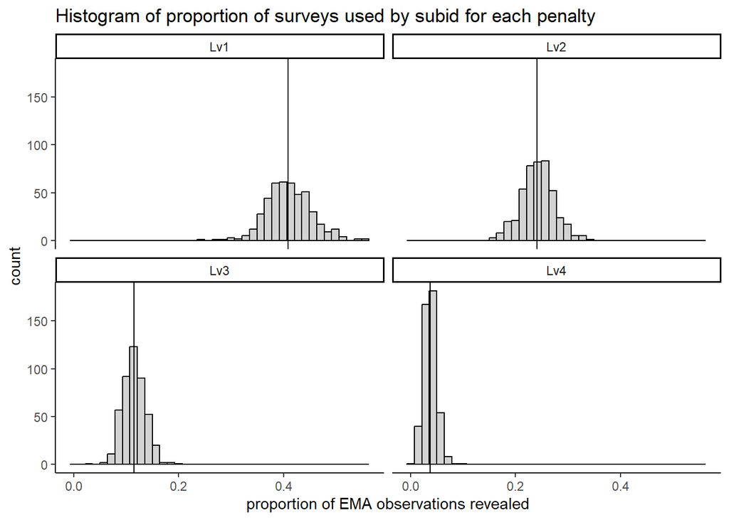

Figure 2

There doesn’t appear to be a relationship between lapse and proportion of EMA surveys revealed.

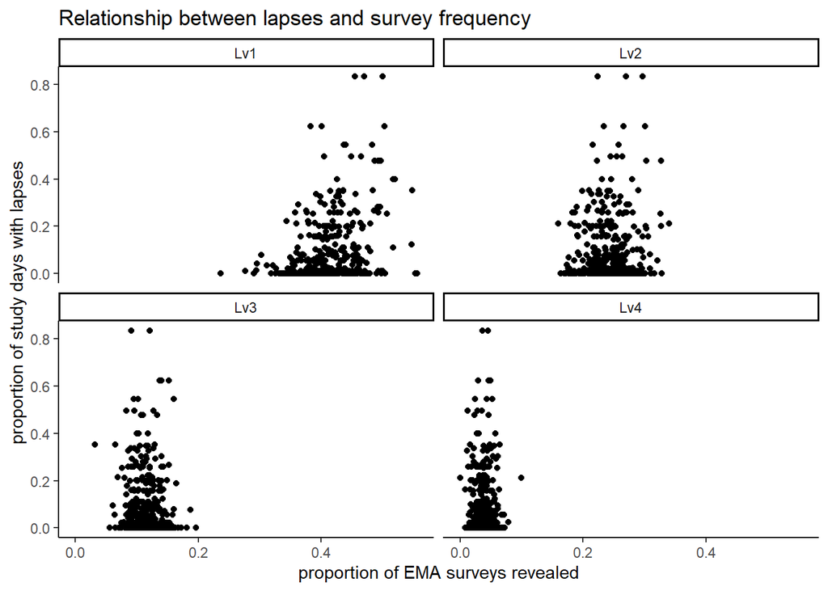

### Model Evaluation

Raw median auROCs for xgboost and five neural net models are presented below.

```
Rows: 1
Columns: 6
$ xgboost <dbl> 0.895
$ nn_full <dbl> 0.88
$ nn_lv1  <dbl> 0.87
$ nn_lv2  <dbl> 0.855
$ nn_lv3  <dbl> 0.835
$ nn_lv4  <dbl> 0.775
```

Median posterior probabilities and 95% Bayesian credible intervals for auROC for the XGBoost and 5 neural network models are presented in the table below.

| model | pp_median | pp_lower | pp_upper |
| --- | --- | --- | --- |
| xgboost | 0.884 | 0.863 | 0.902 |
| no penalty | 0.867 | 0.843 | 0.887 |
| Lv1 | 0.865 | 0.840 | 0.886 |
| Lv2 | 0.856 | 0.831 | 0.878 |
| Lv3 | 0.832 | 0.803 | 0.856 |
| Lv4 | 0.776 | 0.739 | 0.806 |

Potential main figure

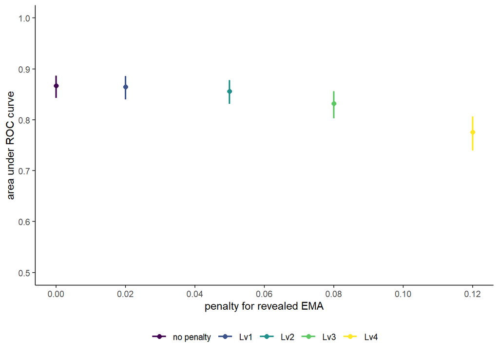

Histograms of posterior probabilities for auROC for the 5 neural network models are presented below.

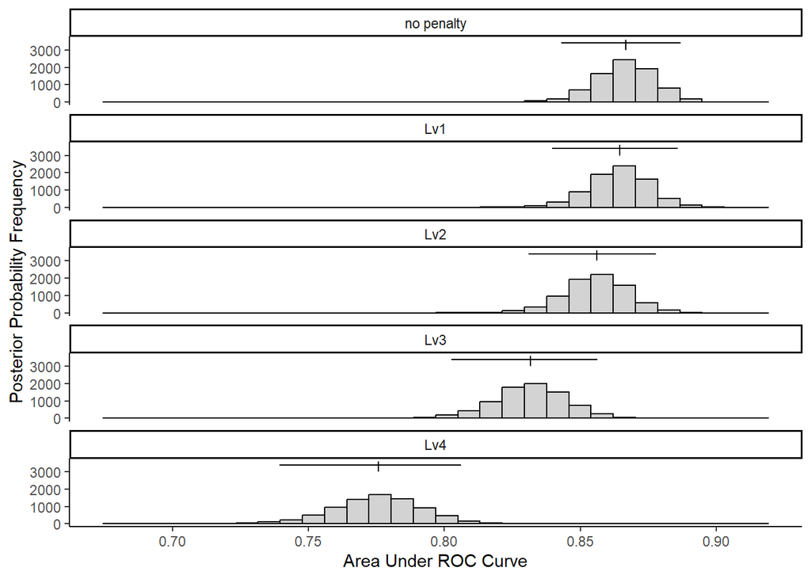

### Model Comparisons

| contrast | probability | mean | lower | upper | median |
| --- | --- | --- | --- | --- | --- |
| nn_full vs. nn_lv1 | 0.666 | 0.002 | -0.006 | 0.011 | 0.002 |
| nn_full vs. nn_lv2 | 0.977 | 0.011 | 0.002 | 0.019 | 0.011 |
| nn_full vs. nn_lv3 | 1.000 | 0.035 | 0.025 | 0.045 | 0.035 |
| nn_full vs. nn_lv4 | 1.000 | 0.091 | 0.078 | 0.105 | 0.091 |

## References

Bae, Sang Won, Brian Suffoletto, Tongze Zhang, Tammy Chung, Melik Ozolcer, Mohammad Rahul Islam, and Anind Dey. 2023. “Leveraging Mobile Phone Sensors, Machine Learning and Explainable Artificial Intelligence to Predict Imminent Same-Day Binge Drinking Events to Support Just-In-Time Adaptive Interventions: A Feasibility Study.” *JMIR Formative Research*, February. https://doi.org/10.2196/39862.

Bae, Sangwon, Tammy Chung, Denzil Ferreira, Anind K. Dey, and Brian Suffoletto. 2018. “Mobile Phone Sensors and Supervised Machine Learning to Identify Alcohol Use Events in Young Adults: Implications for Just-in-Time Adaptive Interventions.” *Addictive Behaviors* 83 (August): 42–47. https://doi.org/10.1016/j.addbeh.2017.11.039.

Businelle, Michael S, Ping Ma, Darla E Kendzor, Summer G Frank, David W Wetter, and Damon J Vidrine. 2016. “Using Intensive Longitudinal Data Collected via Mobile Phone to Detect Imminent Lapse in Smokers Undergoing a Scheduled Quit Attempt.” *Journal of Medical Internet Research* 18 (10): e275. https://doi.org/10/f9bvfc.

Chih, Ming-Yuan, Timothy Patton, Fiona M. McTavish, Andrew J. Isham, Chris L. Judkins-Fisher, Amy K. Atwood, and David H. Gustafson. 2014. “Predictive Modeling of Addiction Lapses in a Mobile Health Application.” *Journal of Substance Abuse Treatment* 46 (1): 29–35. https://doi.org/10.1016/j.jsat.2013.08.004.

Czyz, E. K., H. J. Koo, N. Al-Dajani, C. A. King, and I. Nahum-Shani. 2023. “Predicting Short-Term Suicidal Thoughts in Adolescents Using Machine Learning: Developing Decision Tools to Identify Daily Level Risk After Hospitalization.” *Psychological Medicine* 53 (7): 2982–91. https://doi.org/10.1017/S0033291721005006.

Dumortier, Antoine, Ellen Beckjord, Saul Shiffman, and Ervin Sejdić. 2016. “Classifying Smoking Urges via Machine Learning.” *Computer Methods and Programs in Biomedicine* 137 (December): 203–13. https://doi.org/10.1016/j.cmpb.2016.09.016.

Epstein, David H., Matthew Tyburski, William J. Kowalczyk, Albert J. Burgess-Hull, Karran A. Phillips, Brenda L. Curtis, and Kenzie L. Preston. 2020. “Prediction of Stress and Drug Craving Ninety Minutes in the Future with Passively Collected GPS Data.” *Npj Digital Medicine* 3 (1): 26. https://doi.org/10/ghqvcw.

Hébert, Emily T., Robert Suchting, Chaelin K. Ra, Adam C. Alexander, Darla E. Kendzor, Damon J. Vidrine, and Michael S. Businelle. 2021. “Predicting the First Smoking Lapse During a Quit Attempt: A Machine Learning Approach.” *Drug and Alcohol Dependence* 218 (January): 108340. https://doi.org/10.1016/j.drugalcdep.2020.108340.

Horwitz, Adam, Kaitlyn McCarthy, Stacey L. House, Francesca L. Beaudoin, Xinming An, Thomas C. Neylan, Gari D. Clifford, et al. 2024. “Intensive Longitudinal Assessment Following Index Trauma to Predict Development of PTSD Using Machine Learning.” *Journal of Anxiety Disorders* 104 (June): 102876. https://doi.org/10.1016/j.janxdis.2024.102876.

Jacobson, Nicholas C., and Sukanya Bhattacharya. 2022. “Digital Biomarkers of Anxiety Disorder Symptom Changes: Personalized Deep Learning Models Using Smartphone Sensors Accurately Predict Anxiety Symptoms from Ecological Momentary Assessments.” *Behaviour Research and Therapy* 149 (February): 104013. https://doi.org/10.1016/j.brat.2021.104013.

Jacobson, Nicholas C., and Yeon Joo Chung. 2020. “Passive Sensing of Prediction of Moment-To-Moment Depressed Mood Among Undergraduates with Clinical Levels of Depression Sample Using Smartphones.” *Sensors* 20 (12): 3572. https://doi.org/10.3390/s20123572.

Jones, Andrew, Danielle Remmerswaal, Ilse Verveer, Eric Robinson, Ingmar H. A. Franken, Cheng K. Fred Wen, and Matt Field. 2019. “Compliance with Ecological Momentary Assessment Protocols in Substance Users: A Meta-Analysis.” *Addiction (Abingdon, England)* 114 (4): 609–19. https://doi.org/10/gfsjzg.

Kim, Heejung, SungHee Lee, SangEun Lee, Soyun Hong, HeeJae Kang, and Namhee Kim. 2019. “Depression Prediction by Using Ecological Momentary Assessment, Actiwatch Data, and Machine Learning: Observational Study on Older Adults Living Alone.” *JMIR mHealth and uHealth* 7 (10): e14149. https://doi.org/10.2196/14149.

Mohr, David C., Mi Zhang, and Stephen M. Schueller. 2017. “Personal Sensing: Understanding Mental Health Using Ubiquitous Sensors and Machine Learning.” *Annual Review of Clinical Psychology* 13 (1): 23–47. https://doi.org/10.1146/annurev-clinpsy-032816-044949.

Razavi, Rouzbeh, Amin Gharipour, and Mojgan Gharipour. 2020. “Depression Screening Using Mobile Phone Usage Metadata: A Machine Learning Approach.” *Journal of the American Medical Informatics Association* 27 (4): 522–30. https://doi.org/10.1093/jamia/ocz221.

Roberts, Walter, Yize Zhao, Terril Verplaetse, Kelly E. Moore, MacKenzie R. Peltier, Catherine Burke, Yasmin Zakiniaeiz, and Sherry McKee. 2022. “Using Machine Learning to Predict Heavy Drinking During Outpatient Alcohol Treatment.” *Alcohol: Clinical and Experimental Research* 46 (4): 657–66. https://doi.org/10.1111/acer.14802.

Walters, Scott T., Michael S. Businelle, Robert Suchting, Xiaoyin Li, Emily T. Hébert, and Eun-Young Mun. 2021. “Using Machine Learning to Identify Predictors of Imminent Drinking and Create Tailored Messages for at-Risk Drinkers Experiencing Homelessness.” *Journal of Substance Abuse Treatment* 127 (August): 108417. https://doi.org/10.1016/j.jsat.2021.108417.

Wyant, Kendra, Gaylen Fronk, Jiachen Yu, and John Curtin. in prep. “Lagged Predictions of Next Day Alcohol Use for Adaptive and Personalized Continuing Care,” in prep.

Wyant, Kendra, Hannah Moshontz, Stephanie B. Ward, Gaylen E. Fronk, and John J. Curtin. 2023. “Acceptability of Personal Sensing Among People With Alcohol Use Disorder: Observational Study.” *JMIR mHealth and uHealth* 11 (1): e41833. https://doi.org/10.2196/41833.

Wyant, Kendra, Sarah J. Sant’Ana, Gaylen E. Fronk, and John J. Curtin. 2024. “Machine Learning Models for Temporally Precise Lapse Prediction in Alcohol Use Disorder.” *Journal of Psychopathology and Clinical Science* 133 (7): 527–40. https://doi.org/10.1037/abn0000901.